# Final Project

## Introduction

In this tutorial, I will walk readers through the Data Science Pipeline to gain insights about a new topic. The pipeline includes five principle components; data collection, data management, exploratory analysis, hypothesis testing, and interpretation. To demonstrate this, let's some college hoops data.

Each year, millions of fans from around the world tune in to witness 'March Madness', a single-elimination basketball tournament composed of the 68 U.S. Division 1-A College Basketball teams. The tournament is hosted for both men and women. This past year, a video from Sedona Prince, an Oregon Basketball player, sent the sports world into a tizy. The video included a snippet of the weight facility given to the participants of the Women's March Madness Tournament in comparision to the facility provided for the Men's March Madness Tournament. The inequality between the two was glaring. The video highlighted an ongoing discrepency in the treament of mens vs womens sports. In this project, I plan to look into the income and spending reported by Men's and Women's Division 1-A Basketball teams. Hopefully the paper trail will give us insight into why these inequalities exist.

For more information on the Tweet: https://www.menshealth.com/fitness/a35888671/march-madness-womens-weight-training-facility-twitter-reaction/

## Part 1: Data Collection

The first stage in the Data Science Pipeline is Data Collection/Curation. During this stage, our main goal is to wrangle data from one (or more sources) to base our investigation. For this assignment, I will be using 'All data combined for academic year 2018-19' retreived from https://ope.ed.gov/athletics/#/datafile/list. This source includes robust financial information for post secondary institution athletics within the United States in the 2018-2019 school year.

To get started, we must first import all packages needed to complete this assignment. Then, we will read our data into a pandas DataFrame. In my case, the data is in Excel format so I will use the deafault pandas read_excel() method. This will construct a table that replicates the information found in within my excel source.

```python
from bs4 import BeautifulSoup
from math import nan
from sklearn import linear_model
from statsmodels.formula.api import ols
import requests as rq
import pandas as pd
import numpy as np
import seaborn as sns
import datetime
import matplotlib.pyplot as plt
```

```python
#Scrape Data
table = pd.read_excel('Final Project Data.xlsx')

#Print Result
table.head()
```

|  | unitid | institution_name | addr1_txt | addr2_txt | city_txt | state_cd | zip_text | ClassificationCode | classification_name | ClassificationOther | ... | TOTAL_EXPENSE_ALL_OthSpts | TOTAL_EXPENSE_ALL_Archery | TOTAL_EXPENSE_ALL_Badminton | TOTAL_EXPENSE_ALL_BchVoll | TOTAL_EXPENSE_ALL_Bowling | TOTAL_EXPENSE_ALL_Eqstrian | TOTAL_EXPENSE_ALL_Rodeo | TOTAL_EXPENSE_ALL_Sailing | TOTAL_EXPENSE_ALL_TblTennis | TOTAL_EXPENSE_ALL_WgtLift |
| --- | --- | --- | --- | --- | --- | --- | --- | --- | --- | --- | --- | --- | --- | --- | --- | --- | --- | --- | --- | --- | --- |
| 0 | 100654 | Alabama A & M University | 4900 Meridian Street | NaN | Normal | AL | 35762.0 | 2 | NCAA Division I-FCS | NaN | ... | NaN | NaN | NaN | NaN | 188925.0 | NaN | NaN | NaN | NaN | NaN |
| 1 | 100663 | University of Alabama at Birmingham | Administration Bldg Suite 1070 | NaN | Birmingham | AL | 35294.0 | 1 | NCAA Division I-FBS | NaN | ... | NaN | NaN | NaN | 430503.0 | 339840.0 | NaN | NaN | NaN | NaN | NaN |
| 2 | 100706 | University of Alabama in Huntsville | 301 Sparkman Dr | NaN | Huntsville | AL | 35899.0 | 5 | NCAA Division II without football | NaN | ... | NaN | NaN | NaN | NaN | NaN | NaN | NaN | NaN | NaN | NaN |
| 3 | 100724 | Alabama State University | 915 S Jackson Street | NaN | Montgomery | AL | 36104.0 | 2 | NCAA Division I-FCS | NaN | ... | NaN | NaN | NaN | NaN | 186212.0 | NaN | NaN | NaN | NaN | NaN |
| 4 | 100751 | The University of Alabama | 739 University Blvd | NaN | Tuscaloosa | AL | 35487.0 | 1 | NCAA Division I-FBS | NaN | ... | NaN | NaN | NaN | NaN | NaN | NaN | NaN | NaN | NaN | NaN |

5 rows × 4274 columns

## Part 2: Data Management

The second stage in the Data Science Pipeline is Data Management/Tidying. During this stage we aim to refine our dataset to make it easier to analyze and use. Data Scientists should address missing or innacurate data during this stage to ensure smooth analysis.

Now that we've gathered our data, let's reduce the columns and rows in our table to reflect the attributes and entries we are interested in for this analysis. The following columns were selected from the initial DataFrame and assembled into a new table.

- Insitution Name
- State
- Classification Code
- Classification Name
- Number of Participants: Men's Basketball
- Number of Participants: Women's Basketball
- Expenses: Men's Basketball
- Expenses: Women's Basketball
- Revenue: Men's Basketball
- Revenue: Women's Basketball
- Profit: Men's Basketball
- Profit: Women's Basketball

Additionally, we will only investigate schools with Division 1-A classification, so we can truncate our table to include only entries with a classification code of 1.

```python
#Temporarily save columns of interest for our analysis
colSchool = table['institution_name']
colState = table['state_cd']
colClassCode = table['ClassificationCode']
colClassName = table['classification_name']
colAidMen = table['STUDENTAID_MEN']
colAidWomen = table['STUDENTAID_WOMEN']
colPartBaskMen = table['PARTIC_MEN_Bskball']
colPartBaskWomen = table['PARTIC_WOMEN_Bskball']
colExpBaskMen = table['EXP_MEN_Bskball']
colExpBaskWomen = table['EXP_WOMEN_Bskball']
colRevBaskMen = table['REV_MEN_Bskball']
colRevBaskWomen = table['REV_WOMEN_Bskball']
```

```python
#Construct a DataFrame with columns of interest
revTable = pd.DataFrame(colSchool)
revTable['State'] = colState
revTable['Classification Code'] = colClassCode
revTable['Classification Name'] = colClassName
revTable['Student Aid: Mens Sports'] = colAidMen
revTable['Student Aid: Womens Sports'] = colAidWomen
revTable['Number of Participants: Mens Basketball'] = colPartBaskMen
revTable['Number of Participants: Womens Basketball'] = colPartBaskWomen
revTable['Expenses: Mens Basketball'] = colExpBaskMen
revTable['Expenses: Womens Basketball'] = colExpBaskWomen
revTable['Revenue: Mens Basketball'] = colRevBaskMen
revTable['Revenue: Womens Basketball'] = colRevBaskWomen
revTable['Net Profit: Mens Basketball'] = revTable['Revenue: Mens Basketball'] - revTable['Expenses: Mens Basketball']
revTable['Net Profit: Womens Basketball'] = revTable['Revenue: Womens Basketball'] - revTable['Expenses: Womens Basketball']
```

```python
#Truncate entries to only Division 1-A schools
d1Table = revTable[revTable['Classification Code'] == 1]
d1Table.reset_index(drop = True)

#Print Table
d1Table.head()
```

|  | institution_name | State | Classification Code | Classification Name | Student Aid: Mens Sports | Student Aid: Womens Sports | Number of Participants: Mens Basketball | Number of Participants: Womens Basketball | Expenses: Mens Basketball | Expenses: Womens Basketball | Revenue: Mens Basketball | Revenue: Womens Basketball | Net Profit: Mens Basketball | Net Profit: Womens Basketball |
| --- | --- | --- | --- | --- | --- | --- | --- | --- | --- | --- | --- | --- | --- | --- |
| 1 | University of Alabama at Birmingham | AL | 1 | NCAA Division I-FBS | 4354457.0 | 3245826.0 | 15.0 | 14.0 | 3533944.0 | 2087432.0 | 3628668.0 | 2087432.0 | 94724.0 | 0.0 |
| 4 | The University of Alabama | AL | 1 | NCAA Division I-FBS | 8844926.0 | 7762225.0 | 16.0 | 27.0 | 15966875.0 | 3857300.0 | 16028795.0 | 1046269.0 | 61920.0 | -2811031.0 |
| 7 | Auburn University | AL | 1 | NCAA Division I-FBS | 8807314.0 | 7352381.0 | 19.0 | 21.0 | 10536653.0 | 4536994.0 | 15593947.0 | 538944.0 | 5057294.0 | -3998050.0 |
| 36 | University of South Alabama | AL | 1 | NCAA Division I-FBS | 4271250.0 | 2703903.0 | 14.0 | 14.0 | 2052778.0 | 1463319.0 | 2313701.0 | 1444903.0 | 260923.0 | -18416.0 |
| 40 | Troy University | AL | 1 | NCAA Division I-FBS | 3466524.0 | 2408250.0 | 15.0 | 15.0 | 2604565.0 | 2053677.0 | 2198323.0 | 1316628.0 | -406242.0 | -737049.0 |

## Part 3: Exploratory Data Analysis

The third stage of the Data Science Pipeline is Exploratory Data Analysis. During this stage, we aim to summarize the main characteristics of a given distribution using statistics and visualization.

Now that we only have the data we are concerned with, lets construct some scatterplots to attempt to gain insight into our data.

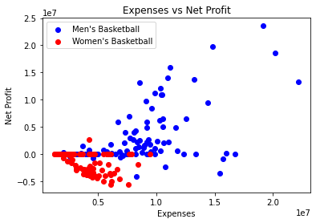

```python
plt.scatter(d1Table['Expenses: Mens Basketball'], d1Table['Net Profit: Mens Basketball'], c = ['Blue'], label = "Men's Basketball")
plt.scatter(d1Table['Expenses: Womens Basketball'], d1Table['Net Profit: Womens Basketball'], c = ['Red'], label = "Women's Basketball")

plt.title('Expenses vs Net Profit')
plt.xlabel('Expenses')
plt.ylabel('Net Profit')
plt.legend()
```

In the plot given above, net profit is plotted with respect to team expenditures for both Men's and Women's Division 1-A College Basketball. The most glaring characteristic from the plot is the lack of profitable women's teams. It appears that their is only one women's team at the Division 1-A level that profits off their basketball program. On the other hand, there are numerous profitable Men's programs. This trend is particularly interesting with respect to our question at hand and deserves further investiagtion.

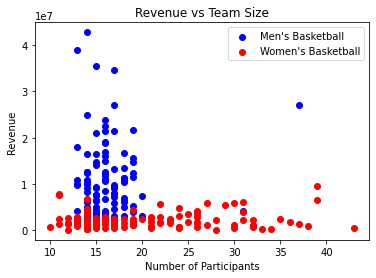

```python
plt.scatter(d1Table['Number of Participants: Mens Basketball'], d1Table['Revenue: Mens Basketball'], color = ['Blue'], label = "Men's Basketball")
plt.scatter(d1Table['Number of Participants: Womens Basketball'], d1Table['Revenue: Womens Basketball'], color = ['Red'], label = "Women's Basketball")

#PLOT AVERAGE

plt.title('Revenue vs Team Size')
plt.xlabel('Number of Participants')
plt.ylabel('Revenue')
plt.legend()
```

In the plot given above, revenue is plotted with respect to the number of participants for Men's and Women's Division 1-A College Basketball. One observation that can be drawn is Men's Basketball appears to have smaller team size on average than Women's teams. The points denoting men's teams clusters between 10-20 participants, while women's teams have a much more sparse distribution. This may partially explain why womens teams lose money on average. A larger team size results in more expenditures and inevitably less profit. Another observation is men's teams clearly tend to produce more revenue on than women's teams. The max Women's revenue is less than 1.5xe^7 while there are numerous Men's teams above this metric.

[figure not shown]

```python
plt.scatter(d1Table['Revenue: Mens Basketball'], d1Table['Student Aid: Mens Sports'], c = ['Blue'], label = "Men's Basketball")
plt.scatter(d1Table['Revenue: Womens Basketball'], d1Table['Student Aid: Womens Sports'], c = ['Red'], label = "Women's Basketball")

plt.title('Team Size vs Revenue')
plt.xlabel('Revenue')
plt.ylabel('Student Aid')
plt.legend()
```

In the plot given above, Student Aid for All Men's and Women's sports is plotted with respect to Men's and Women's Division 1-A College Basketball revenue. We can observe that although men tend to create more revenue for their respective school, the student aid provided for female athletes is very competitive with male student aid. This could be a side-affect of Title IX legislation.

For more information on Title IX: https://www.hhs.gov/civil-rights/for-individuals/sex-discrimination/title-ix-education-amendments/index.html

## Part 4: Hypothesis Testing

The fourth stage of the Data Science Pipeline is Hypothesis Testing. In this stage, we aim to test statistical inferences that may be true for a given dataset.

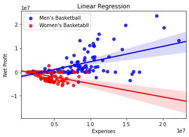

```python
#Initialize a Linear Regression model
lm = linear_model.LinearRegression()

#Construct 2D Array of Men's Data
tmpX = [[x] for x in d1Table['Expenses: Mens Basketball'].values]
tmpY = [[y] for y in d1Table['Net Profit: Mens Basketball'].values]

#Fit the model to Mens data
lm.fit(tmpX, tmpY)
lm.coef_

#Plot data and regression line
sns.regplot(x = 'Expenses: Mens Basketball', y = 'Net Profit: Mens Basketball', data = d1Table, truncate = False, color= 'blue', label = "Men's Basketball")

#Construct 2D Array of Women's Data
tmpX2 = [[x] for x in d1Table['Expenses: Womens Basketball'].values]
tmpY2 = [[y] for y in d1Table['Net Profit: Womens Basketball'].values]

#Fit the model to Womens data
lm.fit(tmpX2, tmpY2)
lm.coef_

#Plot data and regression line
sns.regplot(x = 'Expenses: Womens Basketball', y = 'Net Profit: Womens Basketball', data = d1Table, truncate = False, color= 'red', label = "Women's Basketabll")

#Format Plot
plt.title("Linear Regression")
plt.ylabel("Net Profit")
plt.xlabel("Expenses")
plt.legend()
```

## Part 5: Conclusion

In the fifth and final stage of the Data Science Pipeline, we simply need to evaluate our findings and effectively communicate the insights that we have attained.

In regard to the plots constructed during the Exploratory Data Analysis stage, we learned that men tend to have smaller team sizes on average but generate more revenue at the Division 1-A level. The larger team size of women's teams may play a role in their reduced net profit.

In regard to the plot given above, we notice that their is a linear relationship between Men's Basketball Expenses and Net Profit, as well as, Women's Basketball Expenses and Net Profit. One of the interesting aspects of these two models is their slope. The Men's regression line has a positive slope which indicates Men's basketball teams tend to profit more when spending more, however the Women's regression line has a negative slope which indicates Women's teams tend to profit less when spending more. This is an important consideration when weighing the inequalities of the two tournaments. A team that does not generate as not profit for investors is unlikely to reap the same benefits as a team that does generate high rates of profit.

In the end, there is more information that must be gathered before we reach a conclusion in this matter. There are many factors that affect viewership, amenities, and profit for a given team. Although the expenses and revenue can tell us part of the story, there is still more research to be done here.

Thanks for reading my tutorial!